[figure not shown]

# Final STA141A Report

## Mariia Omelchak ID: 919216079

### Abstract

The key focus of this report is to build a prediction model from the dataset of a Steinmetz et al. (2019) study; for feedback type of mice who are visually stimulated, and rewarded/punished based on their response, specifically the focus of neurological activity 4 seconds post feedback type. Brain area activity, session homogeneity and spices of neurons play a key role in allowing predictions to be built, based on the response of a mouse to a stimuli selection, that encompasses visual, sensory, and choice making neurons. Though utilization of STA141A lectures and discussion notes the creating of this report was possible

### Introduction

The sourse of my data is provided though the STA141A course at UCD, and is a collection of 1-18 sessions (with 100 trials removed from Sessions 1 and 18) of the Steinmetz et al. (2019) study that is described in detail in the Background section of this report.

My question for this report is:

What is an optimal amount and type of brain areas usage to receive positive feedback, and are the outcomes impacted by the gender of mice?

Are vision, action and choice neurons correlated to the gender of mice, and is it a good functional estimate to build a prediction model on?

My setup is to alienate factors and pin them against feedback type in order to determine the most powerful ones that may allow me to form a powerful prediction model. I will then determine an interaction effect between factors that seem inportant to me and demonstrate their impact though visual figures. To train and test the prediction model I am interested in a 80% split of the data, and a clustering method, perhaps a K-means or a KNN methods as those are the most fitting for the size and binomial (1 positive feedback; -1 negative feedback) nature of this dataset.

Key factors I looked into are:

- Gender
- Brain Area Number for Positive Feedback
- Contributing Brain Areas to Positive Feedback
- Left and Right stimuli v.s. Zero and Same stimuli
- Session Number

### Background

The prime method of this report is to create a prediction model, that is capable of predicting feedback type of a trial based on spikes(neurological activity) and stimuli (left, right, same, or none) of the mice.

The data is derived from Steinmetz et al. (2019), where Neuropixels probes were utilized to gather information from 30,000 neurons across 42 brain areas. 10 mice over 39 sessions were used for this study, where they were visually stimulated, of contrasting levels, that are represented by {0, 0.25, 0.50, 1.0}. There are four of the following outcomes that may happen during the study resulting to feed back levels of 1 (rewarded some water) and -1 (mistake and a punishment):

1. Left is brighter than right: 1 when a wheel is turned to the right, and -1 otherwise
2. Right is brighter than left: 1 when a wheel is turned to the left, and -1 otherwise
3. Both sides are equal levels, but not 0: left or right are randomly chosen to be the correct answer
4. Both sides are equal and are 0: 1 is given if the wheel is not turned either way (held still for 1.5s), -1 otherwise

Neurological activity of mice is constructed through three types of neurons: visual, perceptual, and decision making. Such as for example Visual kernel neurons are located in the lateral and primary visual areas cortex of the brain, abbreviated as: VISI, VISp and VISpl.

Sensory neurons are located in the sematorensoty area part of the cortex and are abbreviated such as: SSp and SSs.

### Exploratory Analysis

I began my story of data discovery by initially exploring the factors of success rate, brain area, as well as neuron value.

| mouse_name | n_brain_area | n_neurons | n_trials | success_rate |
| --- | --- | --- | --- | --- |
| Cori | 8 | 734 | 114 | 0.61 |
| Cori | 5 | 1070 | 251 | 0.63 |
| Cori | 11 | 619 | 228 | 0.66 |
| Forssmann | 11 | 1769 | 249 | 0.67 |
| Forssmann | 10 | 1077 | 254 | 0.66 |
| Forssmann | 5 | 1169 | 290 | 0.74 |
| Forssmann | 8 | 584 | 252 | 0.67 |
| Hench | 15 | 1157 | 250 | 0.64 |
| Hench | 12 | 788 | 372 | 0.69 |
| Hench | 13 | 1172 | 447 | 0.62 |
| Hench | 6 | 857 | 342 | 0.80 |
| Lederberg | 12 | 698 | 340 | 0.74 |
| Lederberg | 15 | 983 | 300 | 0.80 |
| Lederberg | 10 | 756 | 268 | 0.69 |
| Lederberg | 8 | 743 | 404 | 0.76 |
| Lederberg | 6 | 474 | 280 | 0.72 |
| Lederberg | 6 | 565 | 224 | 0.83 |
| Lederberg | 10 | 1090 | 216 | 0.81 |

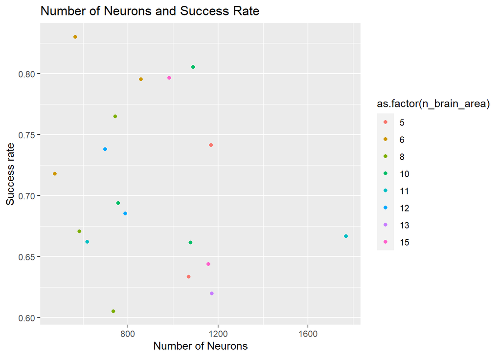

```
##   n_brain_area
##  Min.   : 5.00
##  1st Qu.: 6.50
##  Median :10.00
##  Mean   : 9.50
##  3rd Qu.:11.75
##  Max.   :15.00
```

The first table demonstrates a general layout of the dataset, that is four mice: Cori, Forssmann, Hench, and Laderberg. Their success rate (positive feedback after rotating the wheel in the correct direction or not rotating it at all) is linked to the amount of brain areas that the mice have used, as well as the number of trials and neurons that it took them.

Feedback type is based of the positive retrieval of a reward in form of water (1) and a negative effect, that ( not described explicitly may be no water given to mouse).

There are as mentioned four stimuli conditions, and I will exemplify them (they range 0-1 in 0.25 increments):

- Left: 0.25 and Right: 1 - this is a Right stimuli and will require a mouse to turn the wheel left
- Left : 0.75 and Right: 0.00 - this is a Left stimuli and will require a mouse to turn the wheel right
- Left: 0.00 and Right: 0.00 - this is a Zero stimuli and will require a mouse to keep the wheel straight for 1.5 seconds.
- Left: 0.50 and Right: 0.50 - this is a Same stimuli and will require a mouse to chose one Left or Right direction to turn the wheel to, and the correct decision will be chosen by the people running the experiment (random 50% chance)

In the first “Number of Neurons and Success Rate” graph I explore the relationship between the neurological activity of the mice, the success rate of their responses, as well as the amount of brain areas connected to each of the observations.

The main goal of this task is to determine how many brain areas I want to observe for my final prediction model, since this would give me an optimal amount of intersection in neuron activity. The average number of brain areas is shown to be 9.5, and the median at 10, for the next step I wan tot determine the most significant number of brain areas, especially when the mice are gendered, since the test data will come from female mice (subset from Sessions 1 and 18)

Most observations are clumped below the 1200 number of neurons, yet do demonstrate a wide spread between the success rates. An interesting observation I kept seeing is the importance of 6 brain areas, that produce consistent success levels above 0.72, that is a good indicator for my predictive model.

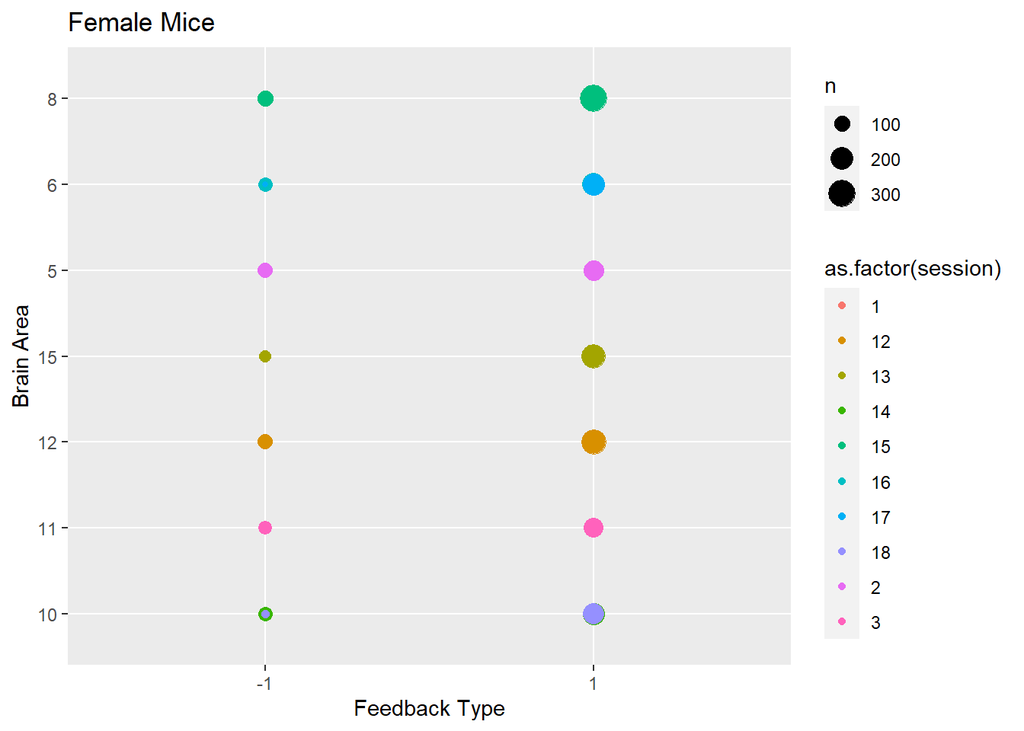

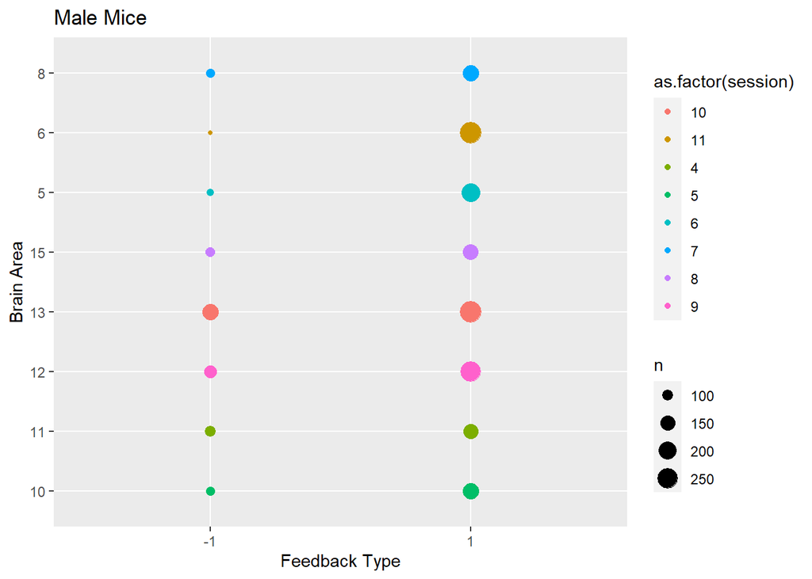

Due to my interest in gendering the mice, I included these two graphs, one for female mice, and another for male mice, and the connection of the amount of brain ares they utilized, in connection to feedback type. And once again 6 brains demonstrates a discrepancy between the quotas of the plots. Now I will demonstrate how I chose the 6 brain areas that I will use as benchmark for my prediction model. Since this is an extremely surface comparison, I wanted to look at a third factor that might contribute to the final prediction model.

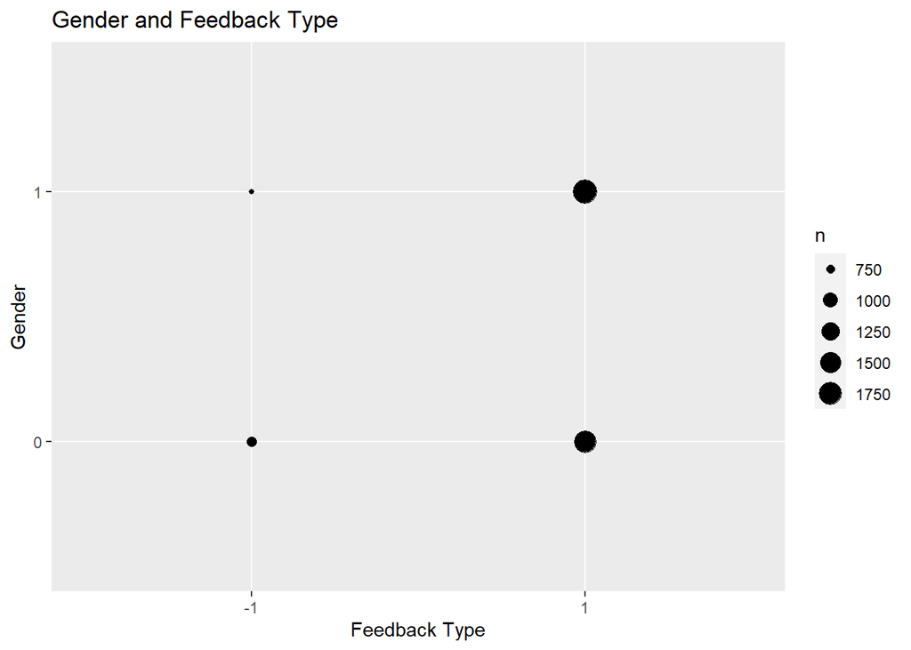

```r
ggplot(data = df, mapping = aes(x = feedback_type, y = gender)) + geom_count() + ggtitle("Gender and Feedback Type ")+ xlab('Feedback Type') + ylab("Gender")
```

This figure cements my choice of the gender factor towards my final model, due to the depicted above density difference between the negative feedback of female mice (1) and male mice(0), specifically in the fact that female mice in fact do show a tendency of being in the negative category more rarely than the male mice.

### Data Integration

I used a behavioral approach to view the i,pact of 6 brain areas that I have mentioned in my data exploration step. As well as the gender difference of the mice.

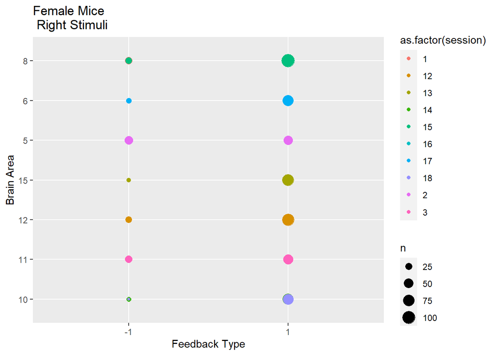

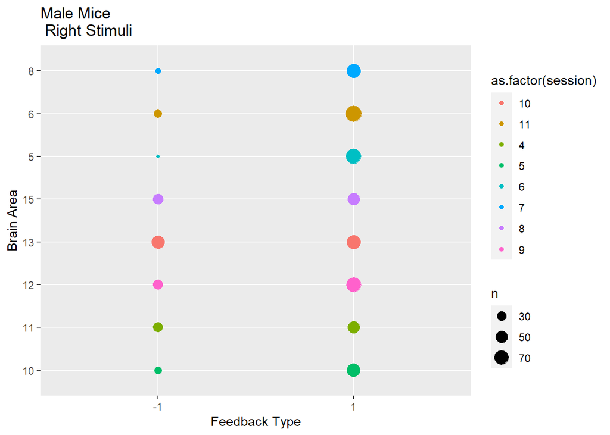

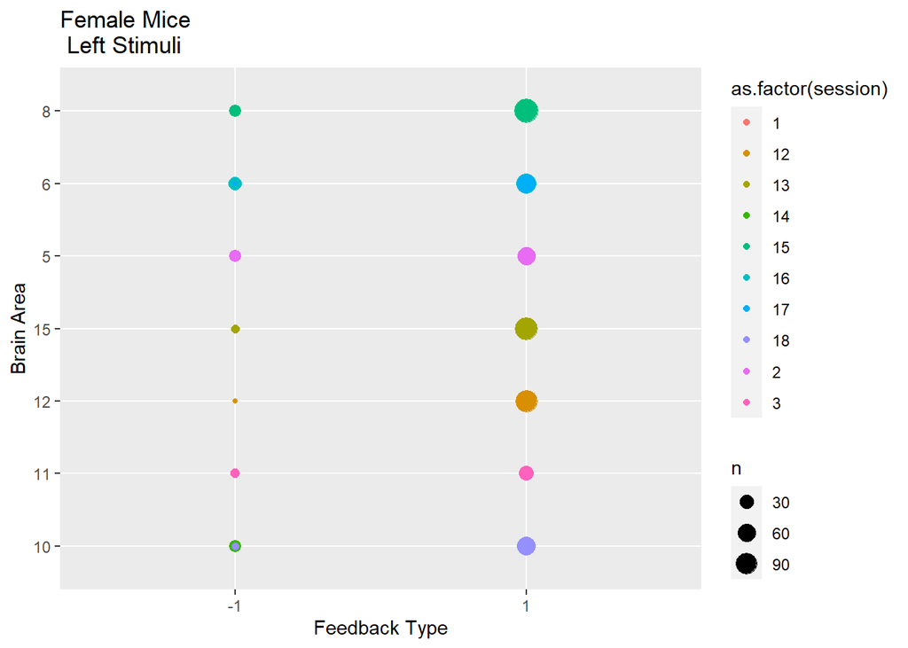

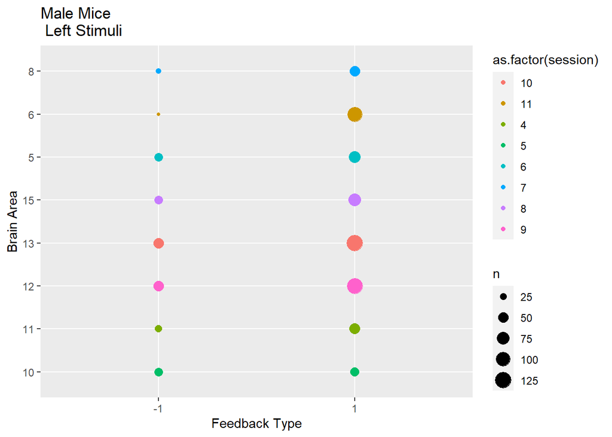

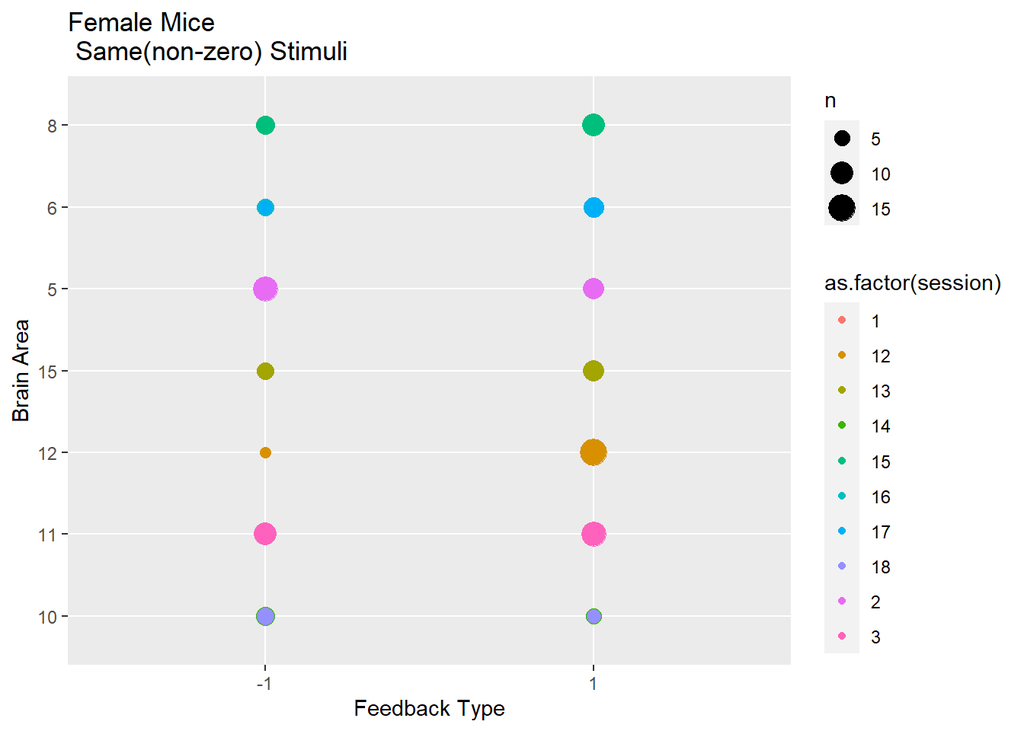

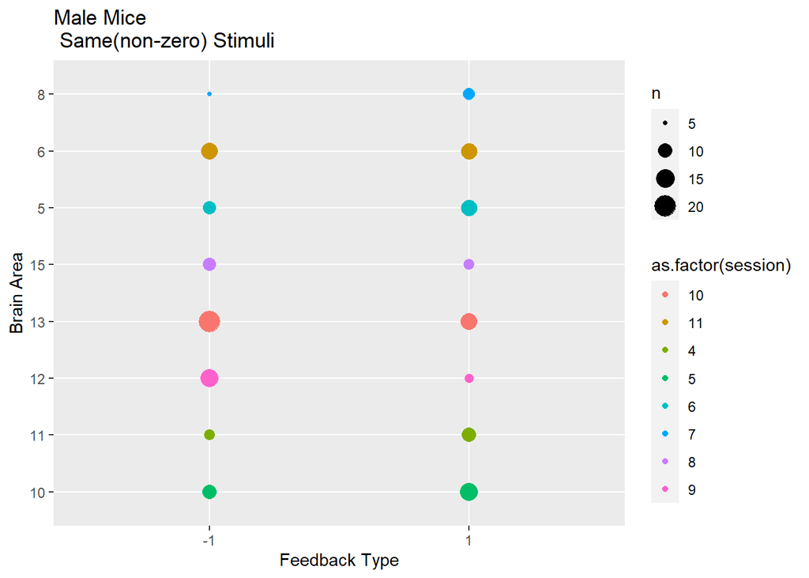

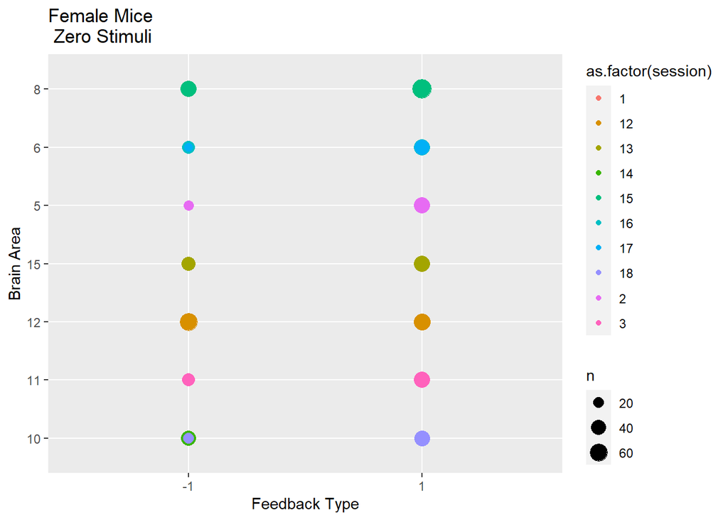

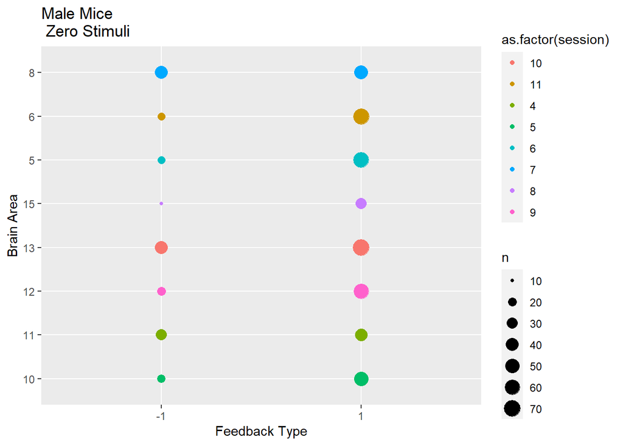

A very interesting observation that I discovered is the visible difference in brain activities of mice with an obvious stimuli (right or left) to that of zero stimulus or same side (aka equal) stimulus. A comment I would like to make, is that for equal stimulus category researchers randomized their decision of whick side was the correct one, thus punishing mice that chose the opposite side, which I think may have created a great confusion for mice, since they work great on repetitive system learning.